# Module 5 Guide

#### **Distributions and Spread**

Understanding distributions helps model and visualize how data points are spread across a range. It also allows us to assess whether the data follow a certain type of distribution (e.g., normal).

For example, you might want to check if the concentration of a pollutant follows a normal distribution in a specific area.

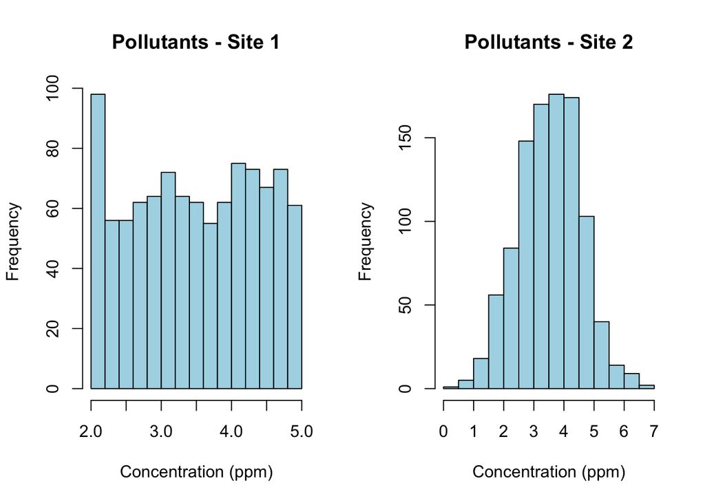

```r
set.seed(124)
# pollutant concentration
concentrations_site1 <- sample(x = seq(from = 2, to = 5, by = 0.1) , size = 1000, replace = TRUE) # random data
concentrations_site2 <- rnorm(n = length(concentrations_site1), mean = mean(concentrations_site1)) # create a more normally distributed dataset

# histogram to visualize the distribution
par(mfrow=c(1,2)) # two plots side-by-side
hist(concentrations_site1, main="Pollutants - Site 1", xlab="Concentration (ppm)", col='lightblue') # plot 1
hist(concentrations_site2, main="Pollutants - Site 2", xlab="Concentration (ppm)", col='lightblue') # plot 2
```

The `hist()` function creates a histogram that shows the distribution of concentrations. By examining the shape of the histogram, you can assess whether the concentrations follow a normal, skewed, or uniform distribution, which informs further statistical analysis.

As discussed above, the **central tendency** and **spread** are two key concepts that help summarize and describe the characteristics of a data distribution. Central Tendency refers to the central point around which data tends to cluster. Common measures of central tendency include the mean and median. This also provides an estimate of the “typical” value within a dataset, but it doesn’t tell us how spread out the values are.

The **sample variance** and **standard deviation** are measurements of the spread or dispersion of a dataset. While variance is indicates how much the individual data points deviate from the mean on average. A small standard deviation means the data points are closely packed around the mean, while a large standard deviation indicates that the data points are spread out over a wider range.

Variance is an important metric using in many algorithms and machine learning. The equations is:

$$s^2 = \frac{1}{n - 1} \sum_{i=1}^n (x_i
- \bar{x})^2$$
- Where $x_i$ is each individual data point, $\bar{x}$ is the sample mean, $n$ is the sample size.

The sample standard deviation is then calculated as the square root of the variance: $\sigma = \sqrt{s^2}$

The `var` and `sd` functions can be used to calculate the sample variance and standard deviation:

```r
data <- c(2, 4, 6, 8, 10)
variance <- var(data) # Sample variance
std_dev <- sd(data) # Sample standard deviation
cat("Sample variance:", variance, "\n",
    " Standard deviation:",  std_dev)
```

```
## Sample variance: 10
##   Standard deviation: 3.162278
```

The units of variance are the square of the units of the original data, which makes it harder to interpret directly in the context of the original data. The standard deviation is typically more easier to interpret because it is in the same units as the data.

For normally distributed data, 68% of the data points fall within one standard deviation above or below the mean. About 95% of the data points are within two standard deviations of the mean. Roughly 99.7% of the data points are within three standard deviations from the mean. Data points beyond the third standard deviation are considered extreme outliers, typically representing less than 0.3% of the data.

These intervals give insight into the distribution and spread of data, with most values concentrated around the mean and fewer values falling as you move further away from it.

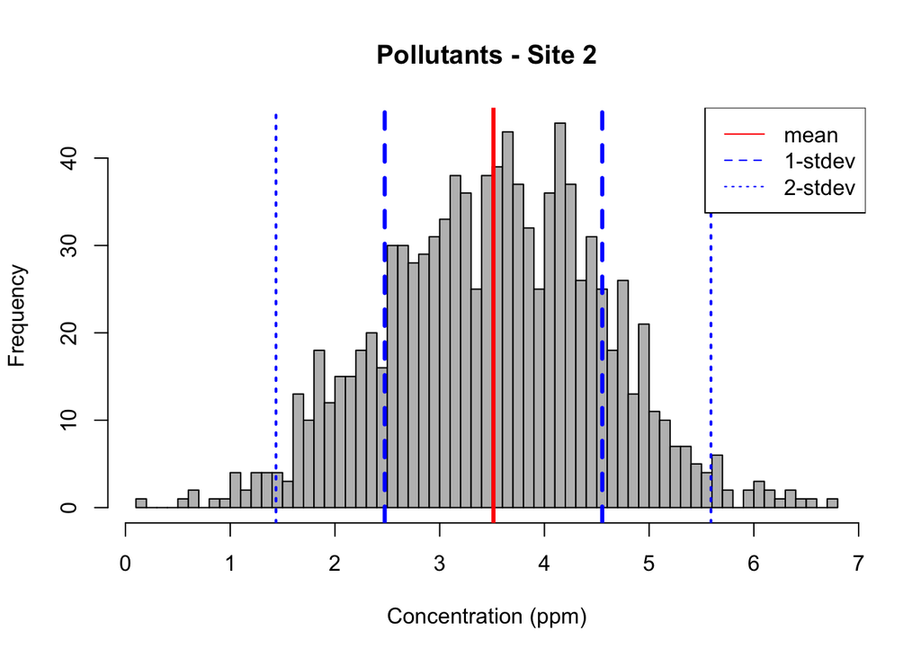

```r
# histogram to visualize the distribution
hist(concentrations_site2, main="Pollutants - Site 2", xlab="Concentration (ppm)", col='gray', breaks = 50) # normally distributed
# add central tendency
cct_mean <- mean(concentrations_site2)
abline(v = cct_mean, col='red', lwd = 3)
# measures of spread
cct_sd <- sd(concentrations_site2)
abline(v = (cct_mean + cct_sd*c(1,-1)) , col='blue', lwd = 3, lty = 2) # 1st std dev
abline(v = (cct_mean + cct_sd*c(2,-2)), col='blue', lwd = 2, lty = 3) # 2nd std dev
legend("topright", c("mean", "1-stdev", "2-stdev"), lty = 1:3, col=c("red","blue","blue"))
```

While not perfect, you can see that this data mostly follows a normal distribution. You can double check this with various tests. The Shapiro-Wilk test is a statistical method used to check if a sample follows a normal distribution. It produces a p-value, and if this p-value is below 0.05, it suggests that the distribution deviates significantly from normal.

```r
shapiro.test(concentrations_site2)
```

```
##
##  Shapiro-Wilk normality test
##
## data:  concentrations_site2
## W = 0.99881, p-value = 0.7589
```

Because the p-value is above 0.05, we can assume the distribution is approximately normal.

These measures are particularly useful for understanding the nature of distributions. For example, in environmental studies, you might look at the **mean temperature** over a year to understand typical conditions and the **standard deviation** to assess the variability in temperature. A small standard deviation could indicate consistent weather patterns, while a larger standard deviation would suggest more fluctuating conditions.

#### **Correlation**

Correlation measures the strength and direction of a linear relationship between two variables. It’s commonly used to understand how changes in one variable might relate to changes in another. You might want to test if there is a correlation between soil temperature and plant growth rate in a study on agricultural land.

```r
# soil temperature and plant growth rate
temp <- c(15, 18, 22, 25, 30)
growth_rate <- c(3, 5, 6, 7, 9)

# correlation between temperature and growth rate
correlation <- cor(temp, growth_rate)
print(correlation)
```

```
## [1] 0.9898031
```

The `cor()` function returns a correlation coefficient (between -1 and 1). A positive value (close to 1) suggests a strong positive correlation (as temperature increases, growth rate also increases), while a negative value indicates an inverse relationship.

**Recall** that strong correlation does not imply causation. So take care of how you report this statistic.

#### **Linear Regression**

Linear regression is used to model the linear relationship between a dependent variable and one or more independent variables. The `lm()` function is used to fit linear models and allows us to predict a continuous outcome based on one or more predictors. The output can be analyzed with `summary()`, `confint()`, and extractor functions for residuals, predictions, etc.

Let’s fit a model for the relationship between `Petal.Length` (the dependent variable) and `Petal.Width` (the independent variable), plot the model fit, and display the model output:

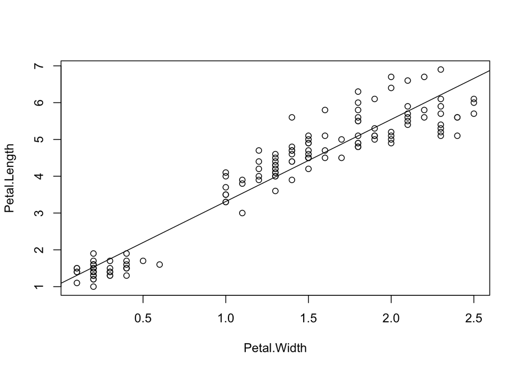

```r
# linear regression model
model <- lm(Petal.Length~Petal.Width, data = iris)
# plot results
plot(Petal.Length~Petal.Width, data = iris)
abline(model)
```

```r
# model summary
summary(model)
```

```
##
## Call:
## lm(formula = Petal.Length ~ Petal.Width, data = iris)
##
## Residuals:
##      Min       1Q   Median       3Q      Max
## -1.33542 -0.30347 -0.02955  0.25776  1.39453
##
## Coefficients:
##             Estimate Std. Error t value Pr(>|t|)
## (Intercept)  1.08356    0.07297   14.85   <2e-16 ***
## Petal.Width  2.22994    0.05140   43.39   <2e-16 ***
## ---
## Signif. codes:  0 '***' 0.001 '**' 0.01 '*' 0.05 '.' 0.1 ' ' 1
##
## Residual standard error: 0.4782 on 148 degrees of freedom
## Multiple R-squared:  0.9271, Adjusted R-squared:  0.9266
## F-statistic:  1882 on 1 and 148 DF,  p-value: < 2.2e-16
```

The `summary()` function then provides detailed results, including several key components:

The model above shows a positive relationship between `Petal.Width` and `Petal.Length`, with a relatively high R-squared, suggests that `Petal.Width` alone does not explain all of the variability in `Petal.Length`.

Linear regression is a powerful tool for exploring relationships between variables. By interpreting the coefficients, R-squared, and p-values, you can gain insights into how well your model fits the data and which variables are significant predictors.

*Other* simple test can also be carried out for hypothesis testing such as t-tests, chi-squared, ANOVA, as well as others. Further statistical tests are beyond the scope of this class and can be explored more *in your own* time!

**Complete the Module Task**